# **Multiple Regression**

**STA4173: Biostatistics**  
Spring 2025

## Introduction

- We have learned simple linear regression,
  $$y = \beta_0 + \beta_1 x + \varepsilon$$
- Today, we will expand to multiple regression, which allows us to include multiple predictors,
  $$y = \beta_0 + \beta_1 x_1 + \beta_2 x_2 + ... + \beta_k x_k + \varepsilon$$
  - Simple linear regression is just a special case of multiple regression, where $k=1$.
- The good news is that all things we learned for simple linear regression hold true for multiple regression! 😎

## R Syntax

- We again use the `lm()` function to define the model and `summary()` to see the results.

```r
m <- lm(outcome ~ predictor_1 + predcitor_2 + ... + predictor_k,
        data = dataset_name)
summary(m)
```

- Additionally, we will find the confidence intervals for the $\beta_i$ using `confint()`.

```r
confint(m) # for 95% CI
confint(m, level = conf_level) # for other levels
```

## Interpretations

- We interpret coefficients much the same as in simple linear regression.
  - Intercept: when [*all* predictors = 0], the average [outcome] is [$\hat{\beta}_0$].
  - Slope: For a 1 [units of predictor $i$] increase in [predictor $i$], we expect [outcome] to [increase or decrease] by [$|\hat{\beta}_i|$] [units of outcome], after controlling for [all other predictors in the model].
    - If $\hat{\beta}_i > 0$, there is an increase.
    - If $\hat{\beta}_i < 0$, there is a decrease.

## Example

- A family doctor wishes to further examine the variables that affect their female patients’ total cholesterol.
- They randomly select 14 female patients, measure their total cholesterol, and asks the patients to determine their average daily consumption of saturated fat.
- The data is as follows,

```r
library(tidyverse)
data <- tibble(age = c(25, 25, 28, 32, 32, 32, 38, 42, 48, 51, 51, 58, 62, 65),
               chol = c(180, 195, 186, 180, 210, 197, 239, 183, 204, 221, 243, 208, 228, 269),
               fat = c(19, 28, 19, 16, 24, 20, 31, 20, 26, 24, 32, 21, 21, 30))
head(data, n = 2)
```

| age | chol | fat |
| --- | --- | --- |
| 25 | 180 | 19 |
| 25 | 195 | 28 |

## Example

- Model total cholesterol ($y$) as a function of age ($x_1$) and daily consumption of saturated fat ($x_2$).

```r
m <- lm(chol ~ age + fat, data = data)
summary(m)
```

```
Call:
lm(formula = chol ~ age + fat, data = data)

Residuals:
    Min      1Q  Median      3Q     Max
-19.874  -8.192   3.479   8.151  14.907

Coefficients:
            Estimate Std. Error t value Pr(>|t|)
(Intercept)  90.8415    15.9887   5.682 0.000142 ***
age           1.0142     0.2427   4.179 0.001540 **
fat           3.2443     0.6632   4.892 0.000478 ***
---
Signif. codes:  0 '***' 0.001 '**' 0.01 '*' 0.05 '.' 0.1 ' ' 1

Residual standard error: 11.42 on 11 degrees of freedom
Multiple R-squared:  0.8473,    Adjusted R-squared:  0.8196
F-statistic: 30.53 on 2 and 11 DF,  p-value: 3.239e-05
```

- The resulting model is
  $$\hat{\text{cholesterol}}_i = 90.842 + 1.014 \text{ age}_i + 3.244 \text{ fat}_i$$

## Example

- Let’s now interpret the slopes from the cholesterol example.
  $$\hat{\text{cholesterol}}_i = 90.842 + 1.014 \text{ age}_i + 3.244 \text{ fat}_i$$
  - For a 1 year increase in age, the cholesterol level is expected to increase by 1.014 mg/dL, after adjusting for the average daily consumption of saturated fat.
  - For a 1 gram increase in average daily consumption of saturated fat, the total cholesterol is expected to increase by 3.244 mg/dL, after adjusting for age.

## Significance of $\beta_i$

- **Hypotheses**
  - $H_0: \ \beta_i = 0$
  - $H_1: \ \beta_i \ne 0$
- **Test Statistic**
  - $t_0 = \frac{\hat{\beta}_i}{\text{SE of }\hat{\beta}_i}$
- *p*-Value
  - $p = 2 \times P[t_{n-k-1} \ge |t_0|]$
- **Rejection Region**
  - Reject $H_0$ if $p<\alpha$.

## Example

- Which, if any, are significant predictors of cholesterol?

```r
summary(m)
```

```
Call:
lm(formula = chol ~ age + fat, data = data)

Residuals:
    Min      1Q  Median      3Q     Max
-19.874  -8.192   3.479   8.151  14.907

Coefficients:
            Estimate Std. Error t value Pr(>|t|)
(Intercept)  90.8415    15.9887   5.682 0.000142 ***
age           1.0142     0.2427   4.179 0.001540 **
fat           3.2443     0.6632   4.892 0.000478 ***
---
Signif. codes:  0 '***' 0.001 '**' 0.01 '*' 0.05 '.' 0.1 ' ' 1

Residual standard error: 11.42 on 11 degrees of freedom
Multiple R-squared:  0.8473,    Adjusted R-squared:  0.8196
F-statistic: 30.53 on 2 and 11 DF,  p-value: 3.239e-05
```

## Example

- **Hypotheses**
  - $H_0: \ \beta_{\text{age}} = 0$
  - $H_1: \ \beta_{\text{age}} \ne 0$
- **Test Statistic and *p*-Value**
  - $t_0 = 4.179$
  - $p = 0.002$
- **Rejection Region**
  - Reject $H_0$ if $p<\alpha$; $\alpha=0.05$
- **Conclusion/Interpretation**
  - Reject $H_0$.
  - There is sufficient evidence to suggest that there is a relationship between age and cholesterol.

## Example

- **Hypotheses**
  - $H_0: \ \beta_{\text{fat}} = 0$
  - $H_1: \ \beta_{\text{fat}} \ne 0$
- **Test Statistic and *p*-Value**
  - $t_0 = 4.892$
  - $p < 0.001$
- **Rejection Region**
  - Reject $H_0$ if $p<\alpha$; $\alpha=0.05$
- **Conclusion/Interpretation**
  - Reject $H_0$.
  - There is sufficient evidence to suggest that there is a relationship between fat and cholesterol.

## Example

- Let’s find the 95% confidence intervals for the regression coefficients.

```r
confint(m)
```

```
                 2.5 %     97.5 %
(Intercept) 55.6507255 126.032306
age          0.4800054   1.548405
fat          1.7845942   4.703937
```

- The 95% CI for $\beta_{\text{age}}$ is (0.48, 1.55).
- The 95% CI for $\beta_{\text{fat}}$ is (1.78, 4.70).

## Reporting Results

- How do I report regression models in the real world?
  - I always give a table of $\hat{\beta}_i$, (95% CI), and $p$-values.
- In our example,

| Predictor | Estimate (95% CI) | *p*-Value |
| --- | --- | --- |
| Age | 1.01 (0.48, 1.55) | 0.002 |
| Fat | 3.24 (1.78, 4.70) | < 0.001 |

## Significant Regression Line

- We can use an $F$-test to test for a significant regression line.
  - A significant regression line means that there is a non-zero slope among all slopes.
  - This makes use of an ANOVA table, however, we will not concern ourselves with the computation.
- The results can be found at the bottom of the `summary()` output.

## Significant Regression Line

- **Hypotheses**
  - $H_0: \ \beta_1 = ... = \beta_k = 0$
  - $H_1:$ at least one is different
- **Test Statistic**
  - $F_0$ (pulled from the `summary()` output)
- *p*-Value
  - $p = \text{P}[F_{k, n-k-1} \ge F_0]$
- **Rejection Region**
  - Reject $H_0$ if $p < \alpha$.

## Example

- Is this a significant regression line?
  - Is at least one of the $x_i$ a significant predictor?
  - Is at least one slope non-zero?

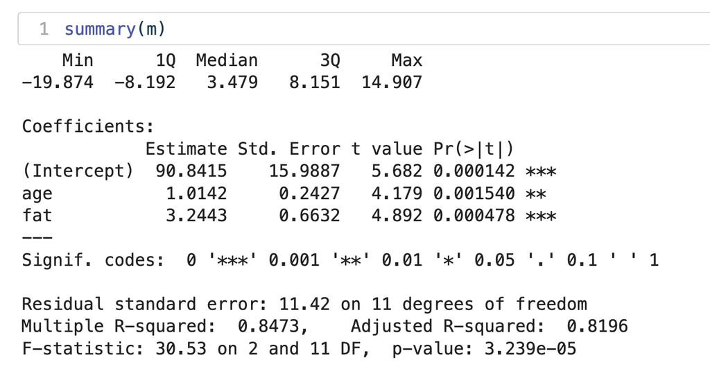

## Example

- **Hypotheses**
  - $H_0: \ \beta_1 = \beta_2 = 0$
  - $H_1:$ at least one is different
- **Test Statistic and *p*-Value**
  - $F_0 = 30.53$
  - $p < 0.001$
- **Rejection Region**
  - Reject $H_0$ if $p < \alpha$; $\alpha=0.05$.
- **Conclusion/Interpretation**
  - Reject $H_0$.
  - There is sufficient evidence to suggest that at least one slope is non-zero.

## Line Fit

- We can assess how well the regression model fits the data using $R^2$.
  $$R^2 = \frac{\text{SS}_{\text{Reg}}}{\text{SS}_{\text{Tot}}}$$
- Thus, $R^2$ is the proportion of variation explained by the model (i.e., predictor set).
- $R^2 \in [0, 1]$
  - $R^2 \to 0$ indicates that the model fits “poorly.”
  - $R^2 \to 1$ indicates that the model fits “well.”
  - $R^2 = 1$ indicates that all points fall on the response surface.

## Line Fit

- Recall that the error term in ANOVA is the “catch all” …
  - The SS<sub>Tot</sub> is constant for the outcome of interest.
  - As we add predictors to the model, we are necessarily increasing SS<sub>Reg</sub>
    - The variance is moving from SS<sub>E</sub> to SS<sub>Reg</sub>
- We do not want to arbitrarily increase $R^2$, so we will use an adjusted version:
  $$R^2_{\text{adj}} = 1 - \frac{\text{MS}_{\text{E}}}{\text{SS}_{\text{Tot}}/\text{df}_{\text{Tot}}}$$

## Example

- The $R^2$ and $R^2_{\text{adj}}$ both come out of the `summary()` function.

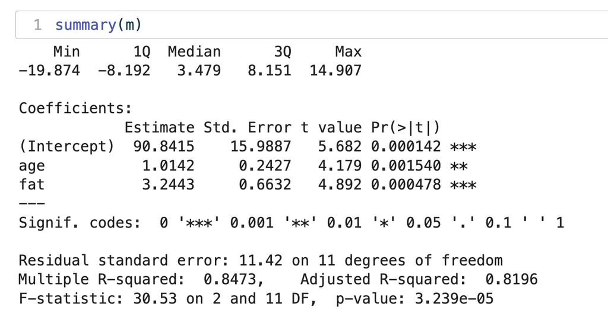

- $R^2$ is 0.847.
- $R^2_{\text{adj}}$ is 0.820 – 82.0% of the variability in cholesterol is explained by the model with age and fat.

## Outliers

- Definition: data values that are much larger or smaller than the rest of the values in the dataset.
- We will look at the standardized residuals,
  $$e_{i_{\text{standardized}}} = \frac{e_i}{\sqrt{\text{MSE}(1-h_i)}},$$
  where
  - $e_i = y_i - \hat{y}_i$ is the residual of the $i$<sup>th</sup> observation
  - $h_i$ is the leverage of the $i$<sup>th</sup> observation
- If $|e_{i_{\text{standardized}}}| > 2.5 \ \to \$ outlier.
- If $|e_{i_{\text{standardized}}}| > 3 \ \to \$ extreme outlier.

## Outliers

- We will use the `rstandard()` function to find the residuals, then we will count the outliers,

```r
dataset_name %>% count(abs(rstandard(m))>2.5)
```

- In our example data,

```r
data %>% count(abs(rstandard(m))>2.5)
```

| abs(rstandard(m)) > 2.5 | n |
| --- | --- |
| FALSE | 14 |

- There are no outliers.
  - (This is Happy Textbook Land!)

## Multicollinearity

- Collinearity/multicollinearity: a correlation between two or more predictor variables affects the estimation procedure.
- We will use the variance inflation factor (VIF) to check for multicollinearity.
  $$\text{VIF}_j = \frac{1}{1-R^2_j},$$
- where
  - $j$ = the predictor of interest and $j \in \{1, 2, ..., k \}$,
  - $R^2_j$ results from regressing $x_j$ on the remaining $(k-1)$ predictors.
- We say that multicollinearity is present if VIF > 10.

## Multicollinearity

- How do we deal with multicollinearity?
  - Easy answer: remove at least one predictor from the collinear set, then reassess VIF.
  - More complicated: how do we know which predictor should be the one removed?
    - (We will likely need to consult with the research team.)

## Multicollinearity

- We will use the [`vif()`](https://www.rdocumentation.org/packages/car/versions/3.1-0/topics/vif) function from the `car` package.

```r
car::vif(m)
```

- There will be a value for each predictor in the model.
- In our cholesterol model,

```r
car::vif(m)
```

```
     age      fat
1.117404 1.117404
```

- No multicollinearity is present.

## Conclusions

- This is just scratching the surface for multiple regression.
- Other statistics courses go deeper into regression topics.
  - Categorical predictors.
  - Interaction terms.
  - Other regression diagnostics.
  - How to handle non-continuous outcomes.